# Marketing Campaigns of Portuguese Bank

SVM classifier

Denaldo Lapi, Francesco Aristei, Samy Chouiti

08 juin 2022

Delete all the possible objects of R that could have been left in memory:

```r
rm(list = ls())
```

### 0.0.1 Load data

```r
load("data.RData")
```

We can change values of the target variable int ‘yes’ and ‘no’:

```r
testData$y <- as.factor(ifelse(testData$y=='1',"yes","no"))
trainingData$y <- as.factor(ifelse(trainingData$y=='1',"yes","no"))
```

Let’s visualize the main statistics of the training data:

```r
library(dplyr)
library(kableExtra)
library(stats)

trainingData %>%
  summary(.) %>%
  kbl(caption = "Basic statistics. Training data") %>%
  kable_classic(full_width = F, html_font = "Cambria")
```

Basic statistics. Training data

|  | ID | age | balance | duration | campaign | previous | poutcome_failure | poutcome_success | poutcome_unknown | job_admin. | job_blue-collar | job_entrepreneur | job_housemaid | job_management | job_retired | job_self-employed | job_services | job_student | job_technician | job_unemployed | job_unknown | marital_divorced | marital_married | marital_single | education_primary | education_secondary | education_tertiary | education_unknown | default_no | … |
| --- | --- | --- | --- | --- | --- | --- | --- | --- | --- | --- | --- | --- | --- | --- | --- | --- | --- | --- | --- | --- | --- | --- | --- | --- | --- | --- | --- | --- | --- | --- |
|  | Min. : 1 | Min. :19.00 | Min. :-2082 | Min. : 4.0 | Min. : 1.00 | Min. : 0.0000 | Min. :0.0000 | Min. :0.00000 | Min. :0.0000 | Min. :0.0000 | Min. :0.0000 | Min. :0.00000 | Min. :0.00000 | Min. :0.0000 | Min. :0.00000 | Min. :0.00000 | Min. :0.00000 | Min. :0.00000 | Min. :0.0000 | Min. :0.00000 | Min. :0.000000 | Min. :0.0000 | Min. :0.0000 | Min. :0.0000 | Min. :0.000 | Min. :0.000 | Min. :0.0000 | Min. :0.00000 | Min. :0.0000 | … |
|  | 1st Qu.:1149 | 1st Qu.:33.00 | 1st Qu.: 68 | 1st Qu.: 104.0 | 1st Qu.: 1.00 | 1st Qu.: 0.0000 | 1st Qu.:0.0000 | 1st Qu.:0.00000 | 1st Qu.:1.0000 | 1st Qu.:0.0000 | 1st Qu.:0.0000 | 1st Qu.:0.00000 | 1st Qu.:0.00000 | 1st Qu.:0.0000 | 1st Qu.:0.00000 | 1st Qu.:0.00000 | 1st Qu.:0.00000 | 1st Qu.:0.00000 | 1st Qu.:0.0000 | 1st Qu.:0.00000 | 1st Qu.:0.000000 | 1st Qu.:0.0000 | 1st Qu.:0.0000 | 1st Qu.:0.0000 | 1st Qu.:0.000 | 1st Qu.:0.000 | 1st Qu.:0.0000 | 1st Qu.:0.00000 | 1st Qu.:1.0000 | … |
|  | Median :2274 | Median :39.00 | Median : 447 | Median : 185.0 | Median : 2.00 | Median : 0.0000 | Median :0.0000 | Median :0.00000 | Median :1.0000 | Median :0.0000 | Median :0.0000 | Median :0.00000 | Median :0.00000 | Median :0.0000 | Median :0.00000 | Median :0.00000 | Median :0.00000 | Median :0.00000 | Median :0.0000 | Median :0.00000 | Median :0.000000 | Median :0.0000 | Median :1.0000 | Median :0.0000 | Median :0.000 | Median :1.000 | Median :0.0000 | Median :0.00000 | Median :1.0000 | … |
|  | Mean :2271 | Mean :41.06 | Mean : 1406 | Mean : 262.1 | Mean : 2.78 | Mean : 0.5792 | Mean :0.1126 | Mean :0.02913 | Mean :0.8583 | Mean :0.1071 | Mean :0.2097 | Mean :0.03606 | Mean :0.02691 | Mean :0.2141 | Mean :0.05132 | Mean :0.04161 | Mean :0.09126 | Mean :0.01775 | Mean :0.1692 | Mean :0.02802 | Mean :0.006935 | Mean :0.1204 | Mean :0.6144 | Mean :0.2652 | Mean :0.152 | Mean :0.511 | Mean :0.2971 | Mean :0.03994 | Mean :0.9834 | … |
|  | 3rd Qu.:3390 | 3rd Qu.:49.00 | 3rd Qu.: 1480 | 3rd Qu.: 328.0 | 3rd Qu.: 3.00 | 3rd Qu.: 0.0000 | 3rd Qu.:0.0000 | 3rd Qu.:0.00000 | 3rd Qu.:1.0000 | 3rd Qu.:0.0000 | 3rd Qu.:0.0000 | 3rd Qu.:0.00000 | 3rd Qu.:0.00000 | 3rd Qu.:0.0000 | 3rd Qu.:0.00000 | 3rd Qu.:0.00000 | 3rd Qu.:0.00000 | 3rd Qu.:0.00000 | 3rd Qu.:0.0000 | 3rd Qu.:0.00000 | 3rd Qu.:0.000000 | 3rd Qu.:0.0000 | 3rd Qu.:1.0000 | 3rd Qu.:1.0000 | 3rd Qu.:0.000 | 3rd Qu.:1.000 | 3rd Qu.:1.0000 | 3rd Qu.:0.00000 | 3rd Qu.:1.0000 | … |
|  | Max. :4520 | Max. :87.00 | Max. :27359 | Max. :2087.0 | Max. :32.00 | Max. :25.0000 | Max. :1.0000 | Max. :1.00000 | Max. :1.0000 | Max. :1.0000 | Max. :1.0000 | Max. :1.00000 | Max. :1.00000 | Max. :1.0000 | Max. :1.00000 | Max. :1.00000 | Max. :1.00000 | Max. :1.00000 | Max. :1.0000 | Max. :1.00000 | Max. :1.000000 | Max. :1.0000 | Max. :1.0000 | Max. :1.0000 | Max. :1.000 | Max. :1.000 | Max. :1.0000 | Max. :1.00000 | Max. :1.0000 | … |

Test data:

```r
testData %>%
  summary(.) %>%
  kbl(caption = "Basic statistics. Test data") %>%
  kable_classic(full_width = F, html_font = "Cambria")
```

Basic statistics. Test data

|  | ID | age | balance | duration | campaign | previous | poutcome_failure | poutcome_success | poutcome_unknown | job_admin. | job_blue-collar | job_entrepreneur | job_housemaid | job_management | job_retired | job_self-employed | job_services | job_student | job_technician | job_unemployed | job_unknown | marital_divorced | marital_married | marital_single | education_primary | education_secondary | education_tertiary | education_unknown | default_no | … |
| --- | --- | --- | --- | --- | --- | --- | --- | --- | --- | --- | --- | --- | --- | --- | --- | --- | --- | --- | --- | --- | --- | --- | --- | --- | --- | --- | --- | --- | --- | --- |
|  | Min. : 6 | Min. :19.00 | Min. : -988.00 | Min. : 5.0 | Min. : 1.000 | Min. : 0.0000 | Min. :0.00000 | Min. :0.00000 | Min. :0.0000 | Min. :0.000 | Min. :0.0000 | Min. :0.00000 | Min. :0.00000 | Min. :0.0000 | Min. :0.00000 | Min. :0.00000 | Min. :0.00000 | Min. :0.00000 | Min. :0.0000 | Min. :0.00000 | Min. :0.00000 | Min. :0.000 | Min. :0.0000 | Min. :0.0000 | Min. :0.0000 | Min. :0.00 | Min. :0.0000 | Min. :0.00000 | Min. :0.0000 | … |
|  | 1st Qu.:1058 | 1st Qu.:34.00 | 1st Qu.: 78.25 | 1st Qu.: 104.0 | 1st Qu.: 1.000 | 1st Qu.: 0.0000 | 1st Qu.:0.00000 | 1st Qu.:0.00000 | 1st Qu.:1.0000 | 1st Qu.:0.000 | 1st Qu.:0.0000 | 1st Qu.:0.00000 | 1st Qu.:0.00000 | 1st Qu.:0.0000 | 1st Qu.:0.00000 | 1st Qu.:0.00000 | 1st Qu.:0.00000 | 1st Qu.:0.00000 | 1st Qu.:0.0000 | 1st Qu.:0.00000 | 1st Qu.:0.00000 | 1st Qu.:0.000 | 1st Qu.:0.0000 | 1st Qu.:0.0000 | 1st Qu.:0.0000 | 1st Qu.:0.00 | 1st Qu.:0.0000 | 1st Qu.:0.00000 | 1st Qu.:1.0000 | … |
|  | Median :2218 | Median :40.00 | Median : 442.50 | Median : 185.0 | Median : 2.000 | Median : 0.0000 | Median :0.00000 | Median :0.00000 | Median :1.0000 | Median :0.000 | Median :0.0000 | Median :0.00000 | Median :0.00000 | Median :0.0000 | Median :0.00000 | Median :0.00000 | Median :0.00000 | Median :0.00000 | Median :0.0000 | Median :0.00000 | Median :0.00000 | Median :0.000 | Median :1.0000 | Median :0.0000 | Median :0.0000 | Median :1.00 | Median :0.0000 | Median :0.00000 | Median :1.0000 | … |
|  | Mean :2210 | Mean :41.54 | Mean : 1378.39 | Mean : 261.9 | Mean : 2.759 | Mean : 0.4035 | Mean :0.09202 | Mean :0.02661 | Mean :0.8814 | Mean :0.102 | Mean :0.2062 | Mean :0.03991 | Mean :0.01663 | Mean :0.2184 | Mean :0.04878 | Mean :0.03548 | Mean :0.09645 | Mean :0.02106 | Mean :0.1741 | Mean :0.02661 | Mean :0.01441 | Mean :0.102 | Mean :0.6341 | Mean :0.2639 | Mean :0.1375 | Mean :0.51 | Mean :0.3049 | Mean :0.04767 | Mean :0.9856 | … |
|  | 3rd Qu.:3375 | 3rd Qu.:48.00 | 3rd Qu.: 1443.25 | 3rd Qu.: 329.0 | 3rd Qu.: 3.000 | 3rd Qu.: 0.0000 | 3rd Qu.:0.00000 | 3rd Qu.:0.00000 | 3rd Qu.:1.0000 | 3rd Qu.:0.000 | 3rd Qu.:0.0000 | 3rd Qu.:0.00000 | 3rd Qu.:0.00000 | 3rd Qu.:0.0000 | 3rd Qu.:0.00000 | 3rd Qu.:0.00000 | 3rd Qu.:0.00000 | 3rd Qu.:0.00000 | 3rd Qu.:0.0000 | 3rd Qu.:0.00000 | 3rd Qu.:0.00000 | 3rd Qu.:0.000 | 3rd Qu.:1.0000 | 3rd Qu.:1.0000 | 3rd Qu.:0.0000 | 3rd Qu.:1.00 | 3rd Qu.:1.0000 | 3rd Qu.:0.00000 | 3rd Qu.:1.0000 | … |
|  | Max. :4521 | Max. :83.00 | Max. :27733.00 | Max. :2029.0 | Max. :28.000 | Max. :24.0000 | Max. :1.00000 | Max. :1.00000 | Max. :1.0000 | Max. :1.000 | Max. :1.0000 | Max. :1.00000 | Max. :1.00000 | Max. :1.0000 | Max. :1.00000 | Max. :1.00000 | Max. :1.00000 | Max. :1.00000 | Max. :1.0000 | Max. :1.00000 | Max. :1.00000 | Max. :1.000 | Max. :1.0000 | Max. :1.0000 | Max. :1.0000 | Max. :1.00 | Max. :1.0000 | Max. :1.00000 | Max. :1.0000 | … |

Variables structure:

```r
str(testData)
```

```
## 'data.frame':    902 obs. of  54 variables:
##  $ ID                   : int  14 51 93 109 111 115 299 300 329 335 ...
##  $ age                  : int  20 45 27 56 21 25 38 32 35 30 ...
##  $ balance              : int  502 844 -195 3391 2488 331 593 759 978 424 ...
##  $ duration             : int  261 1018 391 243 258 170 1484 317 1370 298 ...
##  $ campaign             : int  1 3 1 1 6 4 24 5 3 4 ...
##  $ previous             : int  0 0 0 0 3 0 0 0 3 0 ...
##  $ poutcome_failure     : int  0 0 0 0 0 0 0 0 0 0 ...
##  $ poutcome_success     : int  0 0 0 0 1 0 0 0 1 0 ...
##  $ poutcome_unknown     : int  1 1 1 1 0 1 1 1 0 1 ...
##  $ job_admin.           : int  0 0 0 0 0 0 0 0 0 0 ...
##  $ job_blue-collar      : int  0 1 0 0 0 0 0 1 0 0 ...
##  $ job_entrepreneur     : int  0 0 0 0 0 0 1 0 0 0 ...
##  $ job_housemaid        : int  0 0 0 0 0 0 0 0 0 0 ...
##  $ job_management       : int  0 0 0 0 0 0 0 0 0 1 ...
```

[output cut: 40 more lines]

Levels of the target factor variable:

```r
levels(trainingData$y)
```

```
## [1] "no"  "yes"
```

We can change the levels ordering:

```r
trainingData$y <- relevel(trainingData$y, ref = "yes")
testData$y <- relevel(testData$y, ref = "yes")
levels(trainingData$y)
```

```
## [1] "yes" "no"
```

The positive value is now located on position 1 of the levels.

# 1 SVM classifier

We’ ll use the *caret* package for applying SVM, which performs a non-linear classification using what is called the kernel trick. The most commonly used kernel transformations are polynomial kernel and radial kernel.

At first let’s load the *caret* package:

```r
library("caret")
```

```r
# set seed for repeating the experiments
set.seed(123)
```

We’ll run SVM on the training dataset by applying cross-validation (10-fold):

```r
fitControl <- trainControl(method = "cv",
                           number = 10,
                           # Estimate class probabilities
                           classProbs = TRUE,
                           summaryFunction = prSummary
)
```

## 1.1 SVM with linear kernel

Let’s first run the SVM with a linear kernel, which is a simple linear classifier. For the moment we’ll not apply any kind of hyperparameter tuning. We will use this first SVM model as a baseline for building the following ones. Again we’ll center and scale the variables to make their scale comparable, and we’ll use the *F-score* as a validation metric:

```r
#install.packages("MLmetrics")
library(MLmetrics)
svm.mod1 <- train(y ~ .,
                 data = trainingData, # train data
                 preProcess = c("center","scale"),
                 method = "svmLinear",
                 trControl = fitControl,
                 metric = "F"
)
```

Let’s print the results:

```r
svm.mod1
```

```
## Support Vector Machines with Linear Kernel
##
## 3605 samples
##   53 predictor
##    2 classes: 'yes', 'no'
##
## Pre-processing: centered (53), scaled (53)
## Resampling: Cross-Validated (10 fold)
## Summary of sample sizes: 3245, 3244, 3244, 3245, 3244, 3244, ...
## Resampling results:
##
##   AUC        Precision  Recall     F
##   0.4631069  0.5944854  0.1567364  0.2449171
##
## Tuning parameter 'C' was held constant at a value of 1
```

As shown by the result, the tuning parameter ‘C’ is set to a standard value of 1 (no tuning). This parameter imposes a penalty to the model for making an error: the higher the value of C, the less likely it is that the SVM algorithm will misclassify a point.

Predict test data:

```r
y.svm.pred = predict(svm.mod1, testData)
```

We can show the confusion matrix:

```r
confusionMatrix(y.svm.pred, testData$y, mode = "prec_recall", positive = "yes")
```

```
## Confusion Matrix and Statistics
##
##           Reference
## Prediction yes  no
##        yes  19   5
##        no   85 793
##
##                Accuracy : 0.9002
##                  95% CI : (0.8788, 0.919)
##     No Information Rate : 0.8847
##     P-Value [Acc > NIR] : 0.07755
##
##                   Kappa : 0.2651
##
##  Mcnemar's Test P-Value : < 2e-16
##
##               Precision : 0.79167
##                  Recall : 0.18269
##                      F1 : 0.29688
##              Prevalence : 0.11530
##          Detection Rate : 0.02106
##    Detection Prevalence : 0.02661
##       Balanced Accuracy : 0.58821
##
##        'Positive' Class : yes
##
```

This model has lower performances than our best KNN model.

We can visualize the importance of each variable:

```r
#Variable importance by SVM model
varImp(svm.mod1)
```

```
## ROC curve variable importance
##
##   only 20 most important variables shown (out of 53)
##
##                       Importance
## duration                 100.000
## previous                  30.411
## pdays_Never contacted     29.592
## poutcome_unknown          24.796
## housing_yes               24.094
## housing_no                24.094
## poutcome_success          22.122
## balance                   21.956
## month_may                 21.670
## campaign                  17.407
## marital_married           14.896
## education_tertiary        14.351
## job_blue-collar           13.634
## pdays_Under 6months       12.908
## loan_yes                  12.196
## loan_no                   12.196
## month_oct                 11.035
## job_retired               10.079
## marital_single             9.757
## education_secondary        8.946
```

We can now perform hyperparameter tuning of the ‘C’ parameter: we can create a grid with different values of it:

```r
svm.mod2 <- train(y ~ .,
                 data = trainingData, # train data
                 preProcess = c("center","scale"),
                 method = "svmLinear",
                 trControl = fitControl,
                 tuneGrid = expand.grid(C = seq(0, 2, length = 20)),
                 metric = "F"
)
```

Model:

```r
svm.mod2
```

```
## Support Vector Machines with Linear Kernel
##
## 3605 samples
##   53 predictor
##    2 classes: 'yes', 'no'
##
## Pre-processing: centered (53), scaled (53)
## Resampling: Cross-Validated (10 fold)
## Summary of sample sizes: 3244, 3244, 3245, 3245, 3244, 3244, ...
## Resampling results across tuning parameters:
##
##   C          AUC        Precision  Recall     F
##   0.0000000        NaN        NaN        NaN        NaN
##   0.1052632  0.4721968  0.6045579  0.1616144  0.2513973
##   0.2105263  0.4773421  0.5846861  0.1616144  0.2513925
##   0.3157895  0.4669892  0.5839535  0.1616144  0.2513925
##   0.4210526  0.4734243  0.5795579  0.1616144  0.2508731
##   0.5263158  0.4728581  0.5795579  0.1616144  0.2508538
##   0.6315789  0.4715782  0.5860514  0.1592334  0.2487167
##   0.7368421  0.4750160  0.5880195  0.1592334  0.2486860
##   0.8421053  0.4721434  0.5924151  0.1592334  0.2492247
##   0.9473684  0.4672500  0.5795579  0.1616144  0.2508538
##   1.0526316  0.4645515  0.5946861  0.1616144  0.2516585
##   1.1578947  0.4721444  0.5990818  0.1616144  0.2521972
##   1.2631579  0.4696752  0.5890818  0.1616144  0.2519313
##   1.3684211  0.4746839  0.5824151  0.1640534  0.2539058
##   1.4736842  0.4723761  0.5939535  0.1616144  0.2516585
##   1.5789474  0.4656973  0.5924151  0.1592334  0.2492247
##   1.6842105  0.4705098  0.5839535  0.1616144  0.2513925
##   1.7894737  0.4711091  0.5880195  0.1592334  0.2486860
##   1.8947368  0.4746681  0.5860514  0.1592334  0.2487167
##   2.0000000  0.4654796  0.5880195  0.1592334  0.2486860
##
## F was used to select the optimal model using the largest value.
## The final value used for the model was C = 1.368421.
```

Plot F-score with different values of cost:

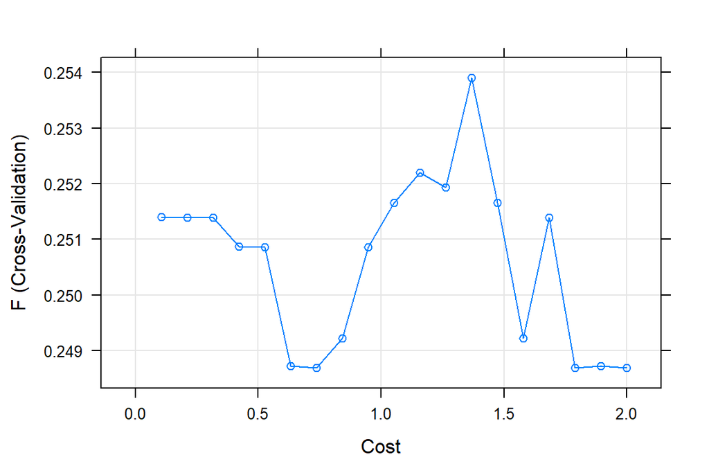

```r
plot(svm.mod2)
```

Print the best tuning parameter C that maximizes model F-score:

```r
svm.mod2$bestTune
```

|  | C |
| --- | --- |
| 14 | 1.368421 |

Predict test data:

```r
y.svm.pred = predict(svm.mod2, testData)
```

Confusion matrix:

```r
confusionMatrix(y.svm.pred, testData$y, mode = "prec_recall", positive = "yes")
```

```
## Confusion Matrix and Statistics
##
##           Reference
## Prediction yes  no
##        yes  19   5
##        no   85 793
##
##                Accuracy : 0.9002
##                  95% CI : (0.8788, 0.919)
##     No Information Rate : 0.8847
##     P-Value [Acc > NIR] : 0.07755
##
##                   Kappa : 0.2651
##
##  Mcnemar's Test P-Value : < 2e-16
##
##               Precision : 0.79167
##                  Recall : 0.18269
##                      F1 : 0.29688
##              Prevalence : 0.11530
##          Detection Rate : 0.02106
##    Detection Prevalence : 0.02661
##       Balanced Accuracy : 0.58821
##
##        'Positive' Class : yes
##
```

As we can see, parameter C doesn’t change the performances.

Variable importance

```r
#Variable importance by SVM model
varImp(svm.mod2)
```

```
## ROC curve variable importance
##
##   only 20 most important variables shown (out of 53)
##
##                       Importance
## duration                 100.000
## previous                  30.411
## pdays_Never contacted     29.592
## poutcome_unknown          24.796
## housing_yes               24.094
## housing_no                24.094
## poutcome_success          22.122
## balance                   21.956
## month_may                 21.670
## campaign                  17.407
## marital_married           14.896
## education_tertiary        14.351
## job_blue-collar           13.634
## pdays_Under 6months       12.908
## loan_yes                  12.196
## loan_no                   12.196
## month_oct                 11.035
## job_retired               10.079
## marital_single             9.757
## education_secondary        8.946
```

## 1.2 SVM with Radial Kernel

*Caret* package allows to use a radial kernel function, that allows to find a non-linear classification boundary among the 2 classes. In this case we’ll use the ‘tuneLength’ parameter which randomly tries several parameters combinations.

```r
svm.mod3 <- train(y ~ .,
                 data = trainingData, # train data
                 preProcess = c("center","scale"),
                 method = "svmRadial",
                 trControl = fitControl,
                 tuneLength = 20,
                 metric = "F"
)
```

```
## line search fails -0.345343 -1.146923 2.01459e-05 3.608389e-06 -7.976256e-09 1.130838e-09 -1.566083e-13
```

Print model:

```r
svm.mod3
```

```
## Support Vector Machines with Radial Basis Function Kernel
##
## 3605 samples
##   53 predictor
##    2 classes: 'yes', 'no'
##
## Pre-processing: centered (53), scaled (53)
## Resampling: Cross-Validated (10 fold)
## Summary of sample sizes: 3244, 3245, 3244, 3245, 3244, 3245, ...
## Resampling results across tuning parameters:
##
##   C          AUC        Precision  Recall      F
##        0.25  0.4301321  0.5749508  0.20255517  0.29478010
##        0.50  0.4295841  0.5870084  0.21707317  0.31198585
##        1.00  0.4303285  0.5619172  0.21225319  0.30297845
##        2.00  0.4311728  0.5366546  0.20987224  0.29762541
##        4.00  0.4152901  0.5181215  0.18106852  0.26488483
##        8.00  0.4057493  0.5234665  0.17619048  0.25720398
##       16.00  0.3936402  0.5060234  0.14970964  0.22682073
##       32.00  0.3892349  0.4897012  0.13768873  0.20820638
##       64.00  0.3836735  0.5334339  0.13542393  0.21072678
##      128.00  0.3641628  0.4961927  0.10644599  0.16982931
##      256.00  0.3445122  0.5050672  0.09901278  0.16027946
##      512.00  0.3297056  0.5195238  0.06747967  0.12880169
##     1024.00  0.3182092  0.5352381  0.05551684  0.10823086
##     2048.00  0.3115910  0.4317569  0.05081301  0.10837417
##     4096.00  0.3071234  0.4833333  0.04105691  0.09271657
##     8192.00  0.2982995  0.4207143  0.04355401  0.09579159
##    16384.00  0.2916549  0.4722222  0.03385598  0.09969089
##    32768.00  0.2905643  0.6145833  0.03135889  0.08161463
##    65536.00  0.2885059  0.3500000  0.02161569  0.08841678
##   131072.00  0.2861707  0.4437500  0.03135889  0.09341501
##
## Tuning parameter 'sigma' was held constant at a value of 0.01459601
## F was used to select the optimal model using the largest value.
## The final values used for the model were sigma = 0.01459601 and C = 0.5.
```

Plot F-score with different values of cost:

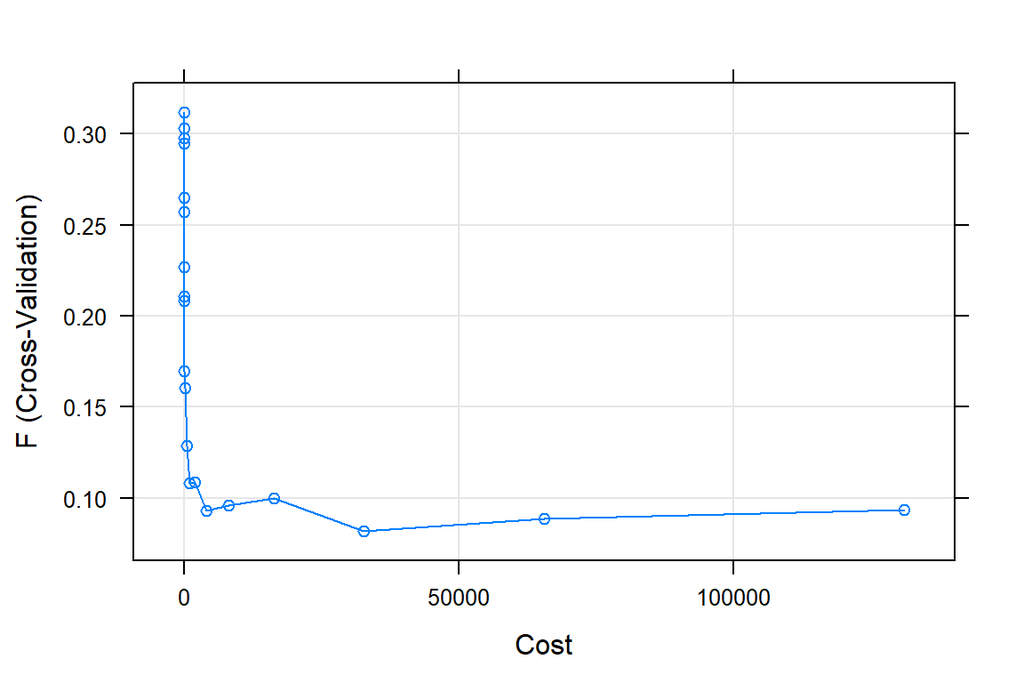

```r
plot(svm.mod3)
```

Print the best tuning parameters that maximize model’s F-score:

```r
svm.mod3$bestTune
```

|  | sigma | C |
| --- | --- | --- |
| 2 | 0.014596 | 0.5 |

Predict test data:

```r
y.svm.pred = predict(svm.mod3, testData)
```

Confusion matrix:

```r
confusionMatrix(y.svm.pred, testData$y, mode = "prec_recall", positive = "yes")
```

```
## Confusion Matrix and Statistics
##
##           Reference
## Prediction yes  no
##        yes  23   7
##        no   81 791
##
##                Accuracy : 0.9024
##                  95% CI : (0.8812, 0.921)
##     No Information Rate : 0.8847
##     P-Value [Acc > NIR] : 0.05056
##
##                   Kappa : 0.3075
##
##  Mcnemar's Test P-Value : 7.149e-15
##
##               Precision : 0.76667
##                  Recall : 0.22115
##                      F1 : 0.34328
##              Prevalence : 0.11530
##          Detection Rate : 0.02550
##    Detection Prevalence : 0.03326
##       Balanced Accuracy : 0.60619
##
##        'Positive' Class : yes
##
```

Variables importance:

```r
#Variable importance by SVM model
varImp(svm.mod3)
```

```
## ROC curve variable importance
##
##   only 20 most important variables shown (out of 53)
##
##                       Importance
## duration                 100.000
## previous                  30.411
## pdays_Never contacted     29.592
## poutcome_unknown          24.796
## housing_yes               24.094
## housing_no                24.094
## poutcome_success          22.122
## balance                   21.956
## month_may                 21.670
## campaign                  17.407
## marital_married           14.896
## education_tertiary        14.351
## job_blue-collar           13.634
## pdays_Under 6months       12.908
## loan_no                   12.196
## loan_yes                  12.196
## month_oct                 11.035
## job_retired               10.079
## marital_single             9.757
## education_secondary        8.946
```

## 1.3 SVM with Polynomial Kernel

*Caret* package allows also to use a polynomial kernel function, that allows to find a non-linear classification boundary among the 2 classes. We’ll use the ‘tuneLength’ parameter which randomly tries several parameters combinations.

```r
svm.mod4 <- train(y ~ .,
                 data = trainingData, # train data
                 preProcess = c("center","scale"),
                 method = "svmPoly",
                 trControl = fitControl,
                 tuneLength = 3,
                 metric = "F"
)
```

```r
svm.mod4
```

```
## Support Vector Machines with Polynomial Kernel
##
## 3605 samples
##   53 predictor
##    2 classes: 'yes', 'no'
##
## Pre-processing: centered (53), scaled (53)
## Resampling: Cross-Validated (10 fold)
## Summary of sample sizes: 3244, 3245, 3244, 3244, 3244, 3245, ...
## Resampling results across tuning parameters:
##
##   degree  scale  C     AUC        Precision  Recall      F
##   1       0.001  0.25  0.4842277  0.6050200  0.15423926  0.2438968
##   1       0.001  0.50  0.4843178  0.6050200  0.15423926  0.2438968
##   1       0.001  1.00  0.4846839  0.6050200  0.15423926  0.2438968
```

[output cut: 27 more lines]

Plot F-score with different values of cost:

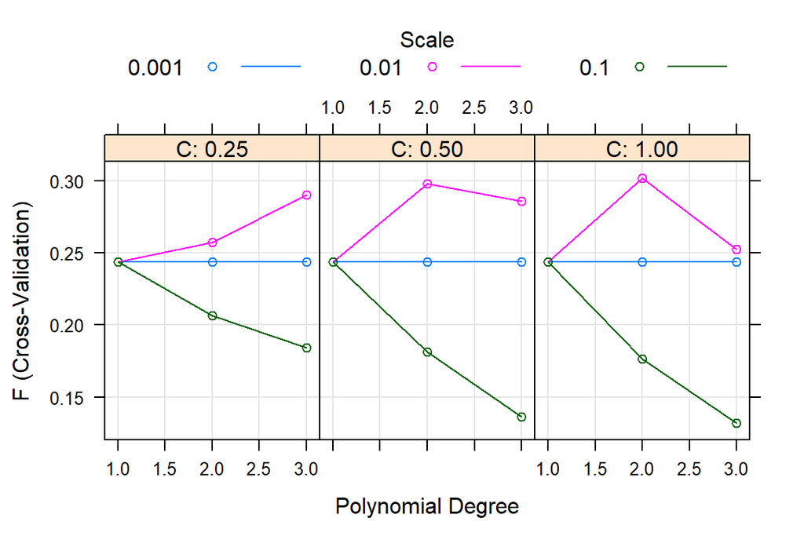

```r
plot(svm.mod4)
```

Print the best tuning parameters that maximize model’s F-score:

```r
svm.mod4$bestTune
```

|  | degree | scale | C |
| --- | --- | --- | --- |
| 15 | 2 | 0.01 | 1 |

Predict test data:

```r
y.svm.pred = predict(svm.mod4, testData)
```

Confusion matrix:

```r
confusionMatrix(y.svm.pred, testData$y, mode = "prec_recall", positive = "yes")
```

```
## Confusion Matrix and Statistics
##
##           Reference
## Prediction yes  no
##        yes  25   9
##        no   79 789
##
##                Accuracy : 0.9024
##                  95% CI : (0.8812, 0.921)
##     No Information Rate : 0.8847
##     P-Value [Acc > NIR] : 0.05056
##
##                   Kappa : 0.3239
##
##  Mcnemar's Test P-Value : 1.903e-13
##
##               Precision : 0.73529
##                  Recall : 0.24038
##                      F1 : 0.36232
##              Prevalence : 0.11530
##          Detection Rate : 0.02772
##    Detection Prevalence : 0.03769
##       Balanced Accuracy : 0.61455
##
##        'Positive' Class : yes
##
```

Variable importance

```r
#Variable importance by SVM model
varImp(svm.mod4)
```

```
## ROC curve variable importance
##
##   only 20 most important variables shown (out of 53)
##
##                       Importance
## duration                 100.000
## previous                  30.411
## pdays_Never contacted     29.592
## poutcome_unknown          24.796
## housing_yes               24.094
## housing_no                24.094
## poutcome_success          22.122
## balance                   21.956
## month_may                 21.670
## campaign                  17.407
## marital_married           14.896
## education_tertiary        14.351
## job_blue-collar           13.634
## pdays_Under 6months       12.908
## loan_yes                  12.196
## loan_no                   12.196
## month_oct                 11.035
## job_retired               10.079
## marital_single             9.757
## education_secondary        8.946
```

# 2 Handling class imbalance

Since the problem we are facing is very challenging due to the fact that one class heavily out-weights the other, we’ll try to adopt some strategies to reduce the effect of this class imbalance on the training of the algorithm.

## 2.1 Down-sampling

We’ll now try to further boost the performance of our algorithm by adopting the down-sampling technique, which consists in removing instances in the majority class. This is one of the many techniques that can be used to deal with an highly imbalanced dataset. In can be easily implemented by using the sampling argument in the ‘trainControl’ function:

```r
fitControl$sampling <- "down"
```

Fit the model:

```r
svm.mod6 <- train(y ~ .,
                 data = trainingData, # train data
                 preProcess = c("center","scale"),
                 method = "svmRadial",
                 trControl = fitControl,
                 tuneLength = 10,
                 metric = "F",
                 verbose = FALSE
)
```

```r
svm.mod6
```

```
## Support Vector Machines with Radial Basis Function Kernel
##
## 3605 samples
##   53 predictor
##    2 classes: 'yes', 'no'
##
## Pre-processing: centered (53), scaled (53)
## Resampling: Cross-Validated (10 fold)
## Summary of sample sizes: 3245, 3244, 3244, 3245, 3245, 3245, ...
## Addtional sampling using down-sampling prior to pre-processing
##
## Resampling results across tuning parameters:
##
##   C       AUC        Precision  Recall     F
##     0.25  0.4053748  0.2898963  0.7659117  0.4201631
##     0.50  0.4526488  0.3193057  0.7661440  0.4503088
##     1.00  0.4563896  0.3241827  0.7926829  0.4590399
##     2.00  0.4518890  0.3378671  0.7975610  0.4740027
##     4.00  0.4567063  0.3241870  0.7781069  0.4568053
##     8.00  0.4292064  0.3298629  0.7831010  0.4638761
##    16.00  0.3867389  0.2975739  0.7903020  0.4317911
##    32.00  0.3709894  0.2709282  0.7204994  0.3935171
##    64.00  0.3289248  0.2606157  0.6960511  0.3786483
##   128.00  0.3197867  0.2564400  0.7231127  0.3783834
##
## Tuning parameter 'sigma' was held constant at a value of 0.0138128
## F was used to select the optimal model using the largest value.
## The final values used for the model were sigma = 0.0138128 and C = 2.
```

Plot F-score with different values of cost:

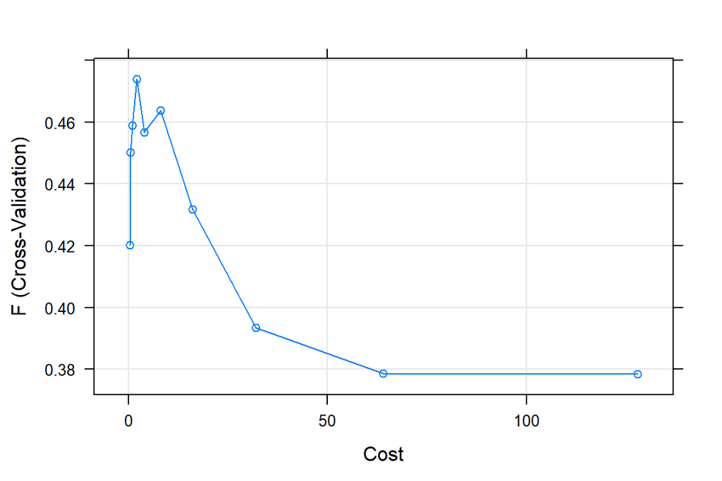

```r
plot(svm.mod6)
```

```r
svm.mod6$bestTune
```

|  | sigma | C |
| --- | --- | --- |
| 4 | 0.0138128 | 2 |

Predict test data:

```r
y.svm.pred = predict(svm.mod6, testData)
```

Confusion matrix:

```r
confusionMatrix(y.svm.pred, testData$y, mode = "prec_recall", positive = "yes")
```

```
## Confusion Matrix and Statistics
##
##           Reference
## Prediction yes  no
##        yes  86 150
##        no   18 648
##
##                Accuracy : 0.8137
##                  95% CI : (0.7868, 0.8386)
##     No Information Rate : 0.8847
##     P-Value [Acc > NIR] : 1
##
##                   Kappa : 0.4117
##
##  Mcnemar's Test P-Value : <2e-16
##
##               Precision : 0.36441
##                  Recall : 0.82692
##                      F1 : 0.50588
##              Prevalence : 0.11530
##          Detection Rate : 0.09534
##    Detection Prevalence : 0.26164
##       Balanced Accuracy : 0.81948
##
##        'Positive' Class : yes
##
```

We’ve achieved a very nice result and improvement with respect to all the previously analyzed models:

- F1 score is 50%
- Balanced Accuracy is 82%

Variables importance:

```r
#Variable importance by SVM model
varImp(svm.mod6)
```

```
## ROC curve variable importance
##
##   only 20 most important variables shown (out of 53)
##
##                       Importance
## duration                 100.000
## previous                  30.411
## pdays_Never contacted     29.592
## poutcome_unknown          24.796
## housing_yes               24.094
## housing_no                24.094
## poutcome_success          22.122
## balance                   21.956
## month_may                 21.670
## campaign                  17.407
## marital_married           14.896
## education_tertiary        14.351
## job_blue-collar           13.634
## pdays_Under 6months       12.908
## loan_yes                  12.196
## loan_no                   12.196
## month_oct                 11.035
## job_retired               10.079
## marital_single             9.757
## education_secondary        8.946
```

## 2.2 Smote

Another possible approach is to apply the so-called Synthetic minority sampling technique (SMOTE), which down samples the majority class and synthesizes new minority instances by interpolating between existing ones.

We add the sampling parameter to the ‘fitControl’ function:

```r
fitControl$sampling <- "smote"
fitControl$verboseIter = FALSE # to visualize running process
```

Fit the model:

```r
svm.mod7 <- train(y ~ .,
                 data = trainingData, # train data
                 preProcess = c("center","scale"),
                 method = "svmRadial",
                 trControl = fitControl,
                 tuneLength = 10,
                 metric = "F",
                 verbose = FALSE
)
```

Print model:

```r
svm.mod7
```

```
## Support Vector Machines with Radial Basis Function Kernel
##
## 3605 samples
##   53 predictor
##    2 classes: 'yes', 'no'
##
## Pre-processing: centered (53), scaled (53)
## Resampling: Cross-Validated (10 fold)
## Summary of sample sizes: 3244, 3244, 3244, 3245, 3245, 3245, ...
## Addtional sampling using SMOTE prior to pre-processing
##
## Resampling results across tuning parameters:
##
##   C       AUC        Precision  Recall     F
##     0.25  0.4626435  0.4603639  0.5567364  0.5023860
##     0.50  0.4594357  0.4841805  0.5519164  0.5137839
##     1.00  0.4434047  0.4662111  0.4797909  0.4711922
##     2.00  0.4127621  0.4632319  0.4217189  0.4400861
##     4.00  0.3940380  0.4617414  0.3685830  0.4087553
##     8.00  0.3857889  0.4586814  0.3349013  0.3859131
##    16.00  0.3640878  0.4441290  0.3203252  0.3713546
##    32.00  0.3575309  0.4568794  0.3301974  0.3827151
##    64.00  0.3341736  0.4231959  0.2914053  0.3441279
##   128.00  0.3267370  0.4100785  0.3059814  0.3493650
##
## Tuning parameter 'sigma' was held constant at a value of 0.01394259
## F was used to select the optimal model using the largest value.
## The final values used for the model were sigma = 0.01394259 and C = 0.5.
```

Plot F-score with different values of cost:

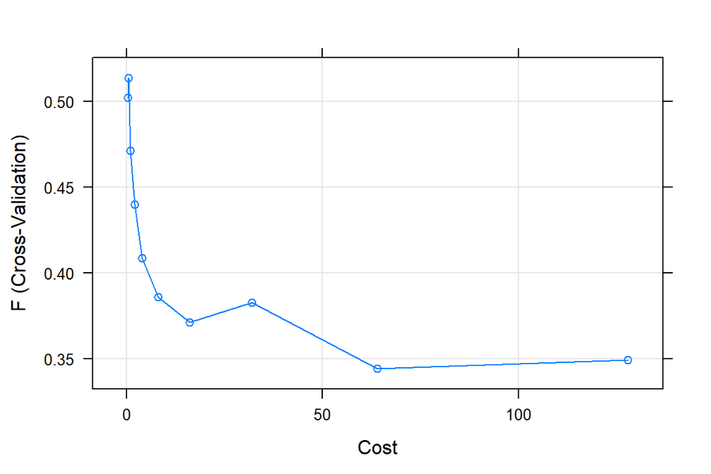

```r
plot(svm.mod7)
```

```r
svm.mod7$bestTune
```

|  | sigma | C |
| --- | --- | --- |
| 2 | 0.0139426 | 0.5 |

Predict test data:

```r
y.svm.pred = predict(svm.mod7, testData)
```

Confusion matrix:

```r
confusionMatrix(y.svm.pred, testData$y, mode = "prec_recall", positive = "yes")
```

```
## Confusion Matrix and Statistics
##
##           Reference
## Prediction yes  no
##        yes  59  58
##        no   45 740
##
##                Accuracy : 0.8858
##                  95% CI : (0.8632, 0.9058)
##     No Information Rate : 0.8847
##     P-Value [Acc > NIR] : 0.4845
##
##                   Kappa : 0.4691
##
##  Mcnemar's Test P-Value : 0.2370
##
##               Precision : 0.50427
##                  Recall : 0.56731
##                      F1 : 0.53394
##              Prevalence : 0.11530
##          Detection Rate : 0.06541
##    Detection Prevalence : 0.12971
##       Balanced Accuracy : 0.74731
##
##        'Positive' Class : yes
##
```

Variables importance:

```r
#Variable importance by SVM model
varImp(svm.mod7)
```

```
## ROC curve variable importance
##
##   only 20 most important variables shown (out of 53)
##
##                       Importance
## duration                 100.000
## previous                  30.411
## pdays_Never contacted     29.592
## poutcome_unknown          24.796
## housing_yes               24.094
## housing_no                24.094
## poutcome_success          22.122
## balance                   21.956
## month_may                 21.670
## campaign                  17.407
## marital_married           14.896
## education_tertiary        14.351
## job_blue-collar           13.634
## pdays_Under 6months       12.908
## loan_no                   12.196
## loan_yes                  12.196
## month_oct                 11.035
## job_retired               10.079
## marital_single             9.757
## education_secondary        8.946
```

### 2.2.1 More hyperparameter tuning

We’ll now try to improve the performance of the model based on down-sampling by trying several hyperparameters configurations.

We first change the ‘sampling’ parameter:

```r
fitControl$sampling <- "down"
```

We now define a list of tuning parameters ‘C’ and ‘sigma’:

```r
grid_radial <- expand.grid(
  sigma = c(0,0.01, 0.02, 0.025, 0.03, 0.04, 0.05, 0.06, 0.07,0.08, 0.09, 0.1,   0.14, 0.25, 0.5,0.75,0.9),
  C = c(0,0.01, 0.05, 0.1, 0.25, 0.5, 0.75, 1, 1.5, 2,5))
```

We can now train the model:

```r
svm.mod8 <- train(y ~ .,
                 data = trainingData, # train data
                 preProcess = c("center","scale"),
                 method = "svmRadial",
                 trControl = fitControl,
                 tuneGrid = grid_radial,
                 tuneLength = 10,
                 metric = "F",
                 verbose = FALSE
)
```

Print model:

```r
svm.mod8
```

```
## Support Vector Machines with Radial Basis Function Kernel
##
## 3605 samples
##   53 predictor
##    2 classes: 'yes', 'no'
##
## Pre-processing: centered (53), scaled (53)
## Resampling: Cross-Validated (10 fold)
## Summary of sample sizes: 3244, 3245, 3245, 3244, 3244, 3244, ...
## Addtional sampling using down-sampling prior to pre-processing
##
## Resampling results across tuning parameters:
##
##   sigma  C     AUC         Precision   Recall      F
##   0.000  0.00         NaN         NaN         NaN         NaN
##   0.000  0.01  0.00000000  0.11511619  1.00000000  0.20646275
##   0.000  0.05  0.00000000  0.11511619  1.00000000  0.20646275
##   0.000  0.10  0.00000000  0.11511619  1.00000000  0.20646275
##   0.000  0.25  0.00000000  0.11511619  1.00000000  0.20646275
##   0.000  0.50  0.00000000  0.11511619  1.00000000  0.20646275
##   0.000  0.75  0.00000000  0.11511619  1.00000000  0.20646275
##   0.000  1.00  0.00000000  0.11511619  1.00000000  0.20646275
##   0.000  1.50  0.00000000  0.11511619  1.00000000  0.20646275
##   0.000  2.00  0.00000000  0.11511619  1.00000000  0.20646275
##   0.000  5.00  0.00000000  0.11511619  1.00000000  0.20646275
##   0.010  0.00         NaN         NaN         NaN         NaN
##   0.010  0.01  0.31551164  0.24920618  0.68670151  0.36437309
##   0.010  0.05  0.31550578  0.24601292  0.66747967  0.35847199
##   0.010  0.10  0.34554407  0.26400002  0.70081301  0.38331509
##   0.010  0.25  0.40584069  0.30331250  0.78298490  0.43648445
##   0.010  0.50  0.45853213  0.33941418  0.79494774  0.47512599
##   0.010  0.75  0.47028241  0.34649502  0.81161440  0.48489892
##   0.010  1.00  0.46996846  0.35031189  0.77799071  0.48250803
##   0.010  1.50  0.47348617  0.34932988  0.82398374  0.49000312
##   0.010  2.00  0.46760708  0.35572237  0.81405343  0.49399072
##   0.010  5.00  0.44228719  0.32763208  0.78269454  0.46118243
##   0.020  0.00         NaN         NaN         NaN         NaN
##   0.020  0.01  0.29747739  0.19968650  0.77334495  0.31723758
##   0.020  0.05  0.31418616  0.21684434  0.74930314  0.33585926
##   0.020  0.10  0.32226952  0.24277633  0.71562137  0.36233936
```

[output cut: 149 more lines]

```
##   0.750  5.00  0.15041320  0.13608100  0.92752613  0.23732479
##   0.900  0.00         NaN         NaN         NaN         NaN
##   0.900  0.01  0.08384835  0.03063626  0.03391405  0.05221364
##   0.900  0.05  0.08601311  0.02949702  0.01451800  0.03639147
##   0.900  0.10  0.12979954  0.09118544  0.68554007  0.17565834
##   0.900  0.25  0.15316266  0.12397199  0.98072009  0.22008633
##   0.900  0.50  0.15413965  0.12570617  0.97108014  0.22255782
##   0.900  0.75  0.15252352  0.13196595  0.93240418  0.23118003
##   0.900  1.00  0.15742599  0.13450517  0.94918699  0.23560471
##   0.900  1.50  0.15485982  0.13389183  0.93269454  0.23413813
##   0.900  2.00  0.15098191  0.13373203  0.92758420  0.23374522
##   0.900  5.00  0.15024290  0.13360705  0.93501742  0.23377506
##
## F was used to select the optimal model using the largest value.
## The final values used for the model were sigma = 0.01 and C = 2.
```

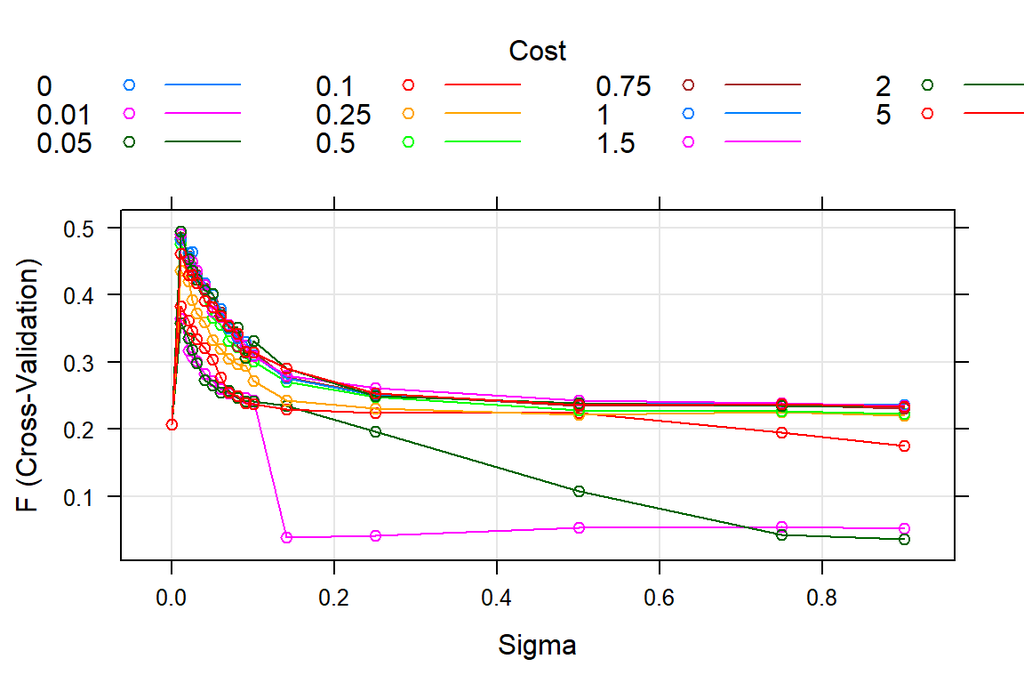

```r
plot(svm.mod8)
```

Predict test data:

```r
y.svm.pred = predict(svm.mod8, testData)
```

Confusion matrix:

```r
confusionMatrix(y.svm.pred, testData$y, mode = "prec_recall", positive = "yes")
```

```
## Confusion Matrix and Statistics
##
##           Reference
## Prediction yes  no
##        yes  83 130
##        no   21 668
##
##                Accuracy : 0.8326
##                  95% CI : (0.8066, 0.8564)
##     No Information Rate : 0.8847
##     P-Value [Acc > NIR] : 1
##
##                   Kappa : 0.4363
##
##  Mcnemar's Test P-Value : <2e-16
##
##               Precision : 0.38967
##                  Recall : 0.79808
##                      F1 : 0.52366
##              Prevalence : 0.11530
##          Detection Rate : 0.09202
##    Detection Prevalence : 0.23614
##       Balanced Accuracy : 0.81758
##
##        'Positive' Class : yes
##
```

Variables importance:

```r
#Variable importance by SVM model
varImp(svm.mod8)
```

```
## ROC curve variable importance
##
##   only 20 most important variables shown (out of 53)
##
##                       Importance
## duration                 100.000
## previous                  30.411
## pdays_Never contacted     29.592
## poutcome_unknown          24.796
## housing_yes               24.094
## housing_no                24.094
## poutcome_success          22.122
## balance                   21.956
## month_may                 21.670
## campaign                  17.407
## marital_married           14.896
## education_tertiary        14.351
## job_blue-collar           13.634
## pdays_Under 6months       12.908
## loan_no                   12.196
## loan_yes                  12.196
## month_oct                 11.035
## job_retired               10.079
## marital_single             9.757
## education_secondary        8.946
```